# Week 5A: Airline Delays

Renee Watson

2026-09-27

# Airline Delays

## Approach

In this assignment, I will analyze arrival performance for Alaska Airlines and AM West across five destinations: Los Angeles, Phoenix, San Diego, San Francisco, and Seattle. The original dataset reports the number of flights that arrived on time and the number that were delayed for each airline and destination. My plan is to first recreate the source data in a CSV file using the same wide format shown in the original table. I will then import the data into R and use functions from dplyr and tidyr to clean and transform the dataset. After filling the missing data, I will transform the data from wide to long format.

Finally, I will calculate and compare delay percentages for the two airlines overall and across each of the five destinations. This will allow me to determine whether the overall airline comparison tells the same story as the city-by-city comparison.

## Codebase

```r
library(tidyr)
library(dplyr)
```

```r
library(ggplot2)
airlines <- data.frame(
  Airline = c("Alaska", NA, NA,"AM WEST", NA),
  Status = c("on time", "delayed", NA, "on time", "delayed"),
  Los_Angeles = c(497, 62, NA, 694, 117),
  Phoenix = c(221, 12, NA, 4840, 415),
  San_Diego = c(212, 20, NA, 383, 65),
  San_Francisco = c(503, 102, NA, 320, 129),
  Seattle = c(1841, 305, NA, 201, 61)
)
airlines
```

```
##   Airline  Status Los_Angeles Phoenix San_Diego San_Francisco Seattle
## 1  Alaska on time         497     221       212           503    1841
## 2    <NA> delayed          62      12        20           102     305
## 3    <NA>    <NA>          NA      NA        NA            NA      NA
## 4 AM WEST on time         694    4840       383           320     201
## 5    <NA> delayed         117     415        65           129      61
```

```r
write.csv(
  airlines,
  "airline_delays.csv",
  row.names = FALSE,
  na = ""
)
```

### Read the Data

```r
airlines_wide <- read.csv(
  "airline_delays.csv",
  na.strings = ""
)
airlines_wide
```

```
##   Airline  Status Los_Angeles Phoenix San_Diego San_Francisco Seattle
## 1  Alaska on time         497     221       212           503    1841
## 2    <NA> delayed          62      12        20           102     305
## 3    <NA>    <NA>          NA      NA        NA            NA      NA
## 4 AM WEST on time         694    4840       383           320     201
## 5    <NA> delayed         117     415        65           129      61
```

### Cleaning Missing Data

```r
airlines_wide <- airlines_wide %>%
  filter(!if_all(everything(), is.na))

airlines_wide<- airlines_wide %>%
  fill(Airline, .direction = "down")
airlines_wide
```

```
##   Airline  Status Los_Angeles Phoenix San_Diego San_Francisco Seattle
## 1  Alaska on time         497     221       212           503    1841
## 2  Alaska delayed          62      12        20           102     305
## 3 AM WEST on time         694    4840       383           320     201
## 4 AM WEST delayed         117     415        65           129      61
```

### Transforming Data from Wide to Long Format

```r
airlines_long <- airlines_wide %>%
  pivot_longer(
    cols = Los_Angeles:Seattle,
    names_to = "City",
    values_to = "Flights"
  )

airlines_long
```

```
## # A tibble: 20 × 4
##    Airline Status  City          Flights
##    <chr>   <chr>   <chr>           <int>
##  1 Alaska  on time Los_Angeles       497
##  2 Alaska  on time Phoenix           221
##  3 Alaska  on time San_Diego         212
##  4 Alaska  on time San_Francisco     503
##  5 Alaska  on time Seattle          1841
##  6 Alaska  delayed Los_Angeles        62
##  7 Alaska  delayed Phoenix            12
##  8 Alaska  delayed San_Diego          20
##  9 Alaska  delayed San_Francisco     102
## 10 Alaska  delayed Seattle           305
## 11 AM WEST on time Los_Angeles       694
## 12 AM WEST on time Phoenix          4840
## 13 AM WEST on time San_Diego         383
## 14 AM WEST on time San_Francisco     320
## 15 AM WEST on time Seattle           201
## 16 AM WEST delayed Los_Angeles       117
## 17 AM WEST delayed Phoenix           415
## 18 AM WEST delayed San_Diego          65
## 19 AM WEST delayed San_Francisco     129
## 20 AM WEST delayed Seattle            61
```

### Count Analysis

```r
count_summary <- airlines_long %>%
  group_by(Airline, Status) %>%
  summarise(
    Total_Flights = sum(Flights),
    .groups = "drop"
  )
count_summary
```

```
## # A tibble: 4 × 3
##   Airline Status  Total_Flights
##   <chr>   <chr>           <int>
## 1 AM WEST delayed           787
## 2 AM WEST on time          6438
## 3 Alaska  delayed           501
## 4 Alaska  on time          3274
```

I performed a count analysis to calculate the total number of on-time and delayed flights for each airline across all five destinations. Alaska had 3,274 on-time flights and 501 delayed flights, while AM West had 6,438 on-time flights and 787 delayed flights.

### Overall Delay Percentage

```r
overall_delay <- airlines_long %>%
  group_by(Airline) %>%
  summarise(
    Total_Flights = sum(Flights),
    Delayed_Flights = sum(Flights[Status == "delayed"]),
    Delay_Percentage = Delayed_Flights / Total_Flights * 100
  )
overall_delay
```

```
## # A tibble: 2 × 4
##   Airline Total_Flights Delayed_Flights Delay_Percentage
##   <chr>           <int>           <int>            <dbl>
## 1 AM WEST          7225             787             10.9
## 2 Alaska           3775             501             13.3
```

AM West had a lower percentage of delayed flights than Alaska. Approximately 10.89% of AM West flights were delayed, compared with 13.27% of Alaska flights. Although AM West had more delayed flights in terms of count, it also had more flights in total.

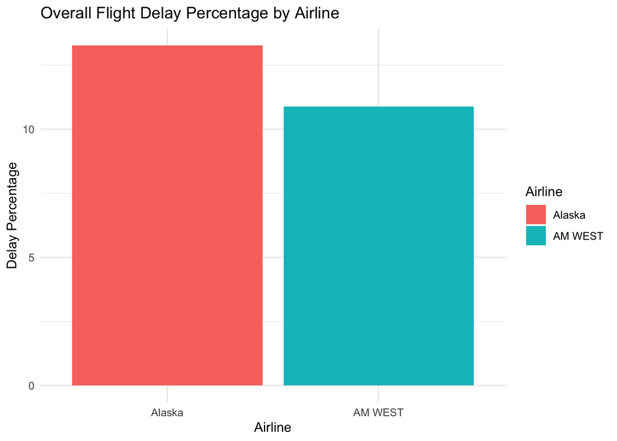

```r
ggplot(overall_delay,
       aes(x = Airline, y = Delay_Percentage, fill = Airline)) +
  geom_col() +
  labs(
    title = "Overall Flight Delay Percentage by Airline",
    x = "Airline",
    y = "Delay Percentage"
    ) +
  theme_minimal()
```

### Delay Percentage by City

```r
city_delay <- airlines_long %>%
  group_by(Airline, City) %>%
  summarise(
    Total_Flights = sum(Flights),
    Delayed_Flights = sum(Flights[Status == "delayed"]),
    Delay_Percentage = Delayed_Flights / Total_Flights * 100,
    .groups = "drop"
  )
city_delay
```

```
## # A tibble: 10 × 5
##    Airline City          Total_Flights Delayed_Flights Delay_Percentage
##    <chr>   <chr>                 <int>           <int>            <dbl>
##  1 AM WEST Los_Angeles             811             117            14.4
##  2 AM WEST Phoenix                5255             415             7.90
##  3 AM WEST San_Diego               448              65            14.5
##  4 AM WEST San_Francisco           449             129            28.7
##  5 AM WEST Seattle                 262              61            23.3
##  6 Alaska  Los_Angeles             559              62            11.1
##  7 Alaska  Phoenix                 233              12             5.15
##  8 Alaska  San_Diego               232              20             8.62
##  9 Alaska  San_Francisco           605             102            16.9
## 10 Alaska  Seattle                2146             305            14.2
```

The city-by-city comparison shows a different pattern from the overall comparison. Alaska airlines had a lower percentage of delayed flights than AM West in all five destinations. Alaska’s delay percentages were approximately 11.09% in Los Angeles, 5.15% in Phoenix, 8.62% in San Diego, 16.86% in San Francisco, and 14.21% in Seattle. In comparison, AM West’s delay percentages were approximately 14.43%, 7.90%, 14.51%, 28.73%, and 23.28%, respectively. These results show that Alaska had the lower delay percentage within every individual destination.

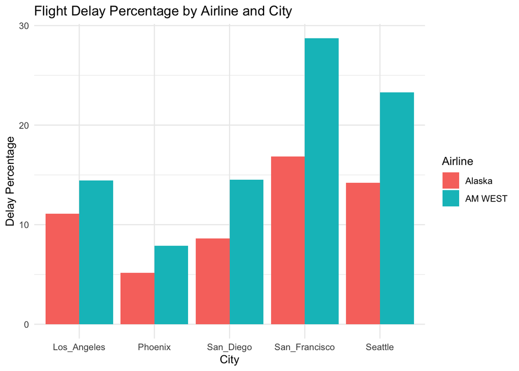

```r
ggplot(city_delay,
       aes(x = City, y = Delay_Percentage, fill = Airline)) +
  geom_col(position = "dodge") +
  labs(
    title = "Flight Delay Percentage by Airline and City",
    x = "City",
    y = "Delay Percentage",
    fill = "Airline"
    ) +
  theme_minimal()
```

### Overall vs. City-by-City Comparison

The overall comparison and the city-by-city comparison show different results. Overall, AM West Airlines had a lower delay percentage of approximately 10.89% compared with 13.27% for Alaska. However, when the airlines were compared within each of the five cities, Alaska had a lower delay percentage in every city. This discrepancy occurs because the two airlines did not have the same distribution of flights across the five cities. AM West had a large proportion of its flights in Phoenix, where delay percentages were relatively low. Of AM West’s 7,225 total flights, 5,255 were in Phoenix. Alaska, on the other hand, had only 233 flights in Phoenix and had a large proportion of its flights in Seattle, where delay percentages were higher. Because the overall percentages combine flights from all five cities, these differences in the number of flights to each destination affect the overall results. This demonstrates why looking only at the overall percentage can be misleading. Examining the airlines city by city provides additional information about their flight performance.

## Conclusion

This analysis compared flight delays for Alaska and AM West airlines across five cities. Overall, AM West had a lower delay percentage of approximately 10.89%, compared with 13.27% for Alaska. However, the city-by-city analysis showed that Alaska had a lower delay percentage than AM West in all five cities. The difference between the overall and city-level results is due to the unequal distribution of flights across destinations. AM West had a large portion of its flights in Phoenix, where delay percentages were relatively low, while Alaska had a large proportion of its flights in Seattle, where delay percentages were higher. This analysis demonstrates the importance of examining both overall and subgroup percentages when comparing performance, since overall results may not show the full pattern in the data.